# linear_models on alpha hill numbers

Adam_Koziol

4/21/2022

setting up the environment

Loading the data

```r
####For some reason the dataframe has duplicates - remove these
alpha_diversity_tax <- read.csv('../hill_numbers/outputsR/diversity_table.csv', header=T, row.names=1) %>%
  unique(.) %>%
  as.tibble
#####Combined dataframe containing functional diversities
alpha_diversity_fd <- read.csv('../hill_numbers/outputsR/diversity_table_fd.csv', header=T, row.names = 1)
####Phylogenetic diversities
alpha_diversity_pd <- read.csv('../hill_numbers/outputsR/diversity_table_pd.csv', header=T, row.names = 1)
#####Metadata
metadata <- read.csv('../data/metadata.csv')
```

Combining the metadata with the dataframes

```r
alph_div_tax_as <- alpha_diversity_tax %>%
  filter(species == 'AS') %>%
  dplyr::select(c(diversity, sample_id)) %>%
  left_join(metadata, by='sample_id') %>%
  mutate(days=case_when(treatment == 'Day1' ~ 0,
                        treatment == 'Acc' ~ 7,
                        treatment == 'Heat' ~ 19,
                        treatment == 'Cold' ~ 33,
                        treatment == 'Diet' ~ 45)) %>%
  mutate(treatment = factor(treatment, levels = c('Day1', 'Acc', 'Heat', 'Cold', 'Diet')))

alph_div_tax_cr <- alpha_diversity_tax %>%
  filter(species == 'CR') %>%
  dplyr::select(c(diversity, sample_id)) %>%
  left_join(metadata, by='sample_id') %>%
  mutate(days=case_when(treatment == 'Day1' ~ 0,
                        treatment == 'Acc' ~ 7,
                        treatment == 'Heat' ~ 19,
                        treatment == 'Cold' ~ 33,
                        treatment == 'Diet' ~ 45),
         cage=case_when(cage == 1 ~ 6,
                        cage == 2 ~ 7,
                        cage == 3 ~ 8,
                        cage == 4 ~ 9,
                        cage == 5 ~ 10,
                        cage == 6 ~ 11)) %>%
  mutate_at(2:8, as.factor) %>%
  mutate(treatment = factor(treatment, levels = c('Day1', 'Acc', 'Heat', 'Cold', 'Diet')))

alph_div_fd_as <- alpha_diversity_fd %>%
  filter(species == 'AS') %>%
  dplyr::select(c(Q, sample_id)) %>%
  left_join(metadata, by='sample_id') %>%
  filter(treatment != 'FAST') %>%
  mutate(days=case_when(treatment == 'Day1' ~ 0,
                        treatment == 'Acc' ~ 7,
                        treatment == 'Heat' ~ 19,
                        treatment == 'Cold' ~ 33,
                        treatment == 'Diet' ~ 45)) %>%
  mutate_at(2:8, as.factor) %>%
  mutate(treatment = factor(treatment, levels = c('Day1', 'Acc', 'Heat', 'Cold', 'Diet')))

alph_div_fd_cr <- alpha_diversity_fd %>%
  filter(species == 'CR') %>%
  dplyr::select(c(Q, sample_id)) %>%
  left_join(metadata, by='sample_id') %>%
  mutate(days=case_when(treatment == 'Day1' ~ 0,
                        treatment == 'Acc' ~ 7,
                        treatment == 'Heat' ~ 19,
                        treatment == 'Cold' ~ 33,
                        treatment == 'Diet' ~ 45),
         cage=case_when(cage == 1 ~ 6,
                        cage == 2 ~ 7,
                        cage == 3 ~ 8,
                        cage == 4 ~ 9,
                        cage == 5 ~ 10,
                        cage == 6 ~ 11)) %>%
  mutate_at(2:8, as.factor) %>%
  mutate(treatment = factor(treatment, levels = c('Day1', 'Acc', 'Heat', 'Cold', 'Diet')))

alph_div_pd_as <- alpha_diversity_pd %>%
  filter(species == 'AS') %>%
  dplyr::select(c(diversity, sample_id)) %>%
  left_join(metadata, by='sample_id') %>%
  filter(treatment != 'FAST') %>%
  mutate(days=case_when(treatment == 'Day1' ~ 0,
                        treatment == 'Acc' ~ 7,
                        treatment == 'Heat' ~ 19,
                        treatment == 'Cold' ~ 33,
                        treatment == 'Diet' ~ 45)) %>%
  mutate_at(2:8, as.factor) %>%
  mutate(treatment = factor(treatment, levels = c('Day1', 'Acc', 'Heat', 'Cold', 'Diet')))

alph_div_pd_cr <- alpha_diversity_pd %>%
  filter(species == 'CR') %>%
  dplyr::select(c(diversity, sample_id)) %>%
  left_join(metadata, by='sample_id') %>%
  mutate(days=case_when(treatment == 'Day1' ~ 0,
                        treatment == 'Acc' ~ 7,
                        treatment == 'Heat' ~ 19,
                        treatment == 'Cold' ~ 33,
                        treatment == 'Diet' ~ 45),
         cage=case_when(cage == 1 ~ 6,
                        cage == 2 ~ 7,
                        cage == 3 ~ 8,
                        cage == 4 ~ 9,
                        cage == 5 ~ 10,
                        cage == 6 ~ 11)) %>%
  mutate_at(2:8, as.factor) %>%
  mutate(treatment = factor(treatment, levels = c('Day1', 'Acc', 'Heat', 'Cold', 'Diet')))
```

Sanity check of each factor

```r
sapply(alph_div_tax_as, mode)
```

```
##     diversity     sample_id             X individual_id     treatment
##     "numeric"   "character"     "numeric"   "character"     "numeric"
##          cage           sex       species          days
##     "numeric"   "character"   "character"     "numeric"
```

```r
contr <- rbind("Day1-Acc" = c(1, -1, 0, 0, 0),
               "Acc-Heat" = c(0, 1, -1, 0, 0),
               "Heat-Cold" = c(0, 0, 1,-1, 0),
               "Cold-Diet" = c(0, 0, 0, 1,-1))
contr_cr <- rbind("Day1-Acc" = c(1, -1, 0, 0, 0),
               "Acc-Heat" = c(0, 1, -1, 0, 0),
               "Heat-Cold" = c(0, 0, 1,-1, 0),
               "Cold-Diet" = c(0, 0, 0, 1,-1))
```

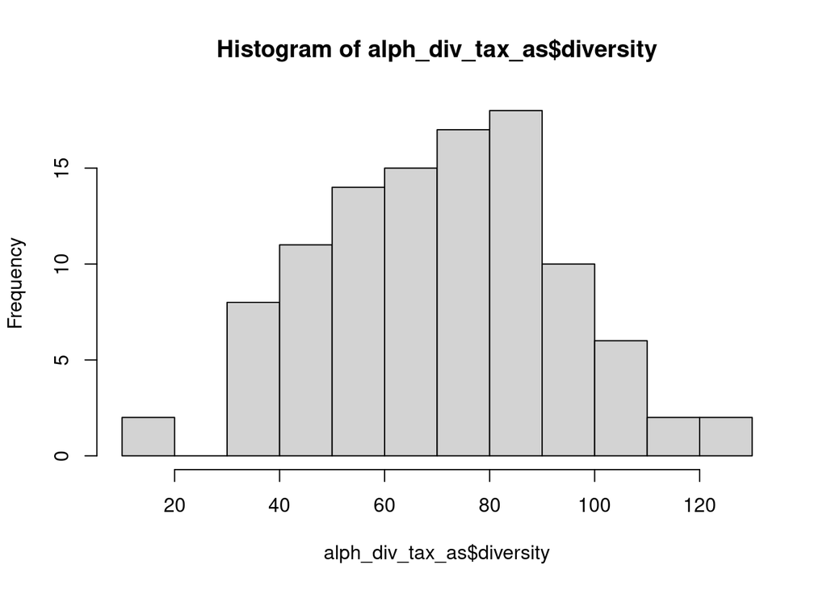

```r
hist(alph_div_tax_as$diversity)
```

treatment_wise_boxplots from the taxonomic diversity Hill numbers

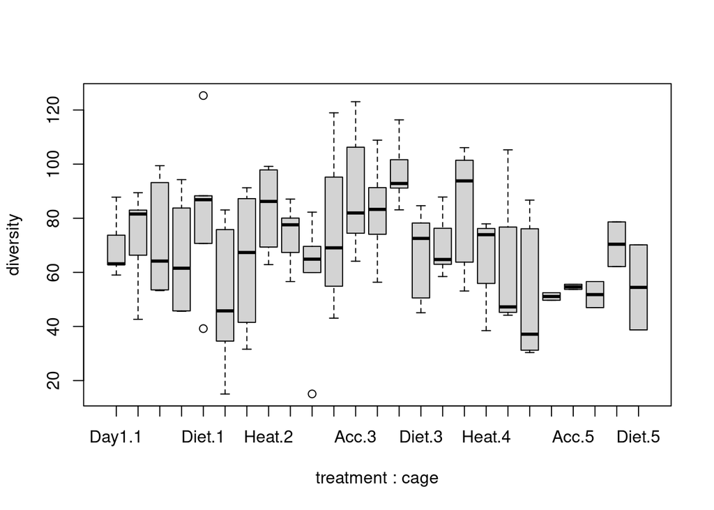

```r
boxplot(diversity~treatment*cage,data = alph_div_tax_as)
```

Assessment of log transformation it looks tighter, however the non-transformed data still looks ok to me so i will continue with this

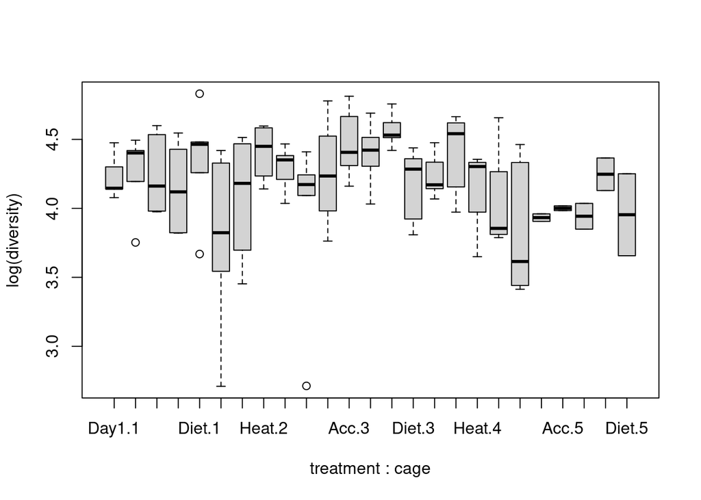

```r
boxplot(log(diversity)~treatment*cage,data = alph_div_tax_as)
```

Create the models for comparison - including the random effects results in the lowest AIC

```r
###Try to include the other factors
model_as.a <- lme(diversity~treatment,
                  random = ~1|cage/individual_id,
                  correlation = corCAR1(form = ~ as.numeric(days)),
                  data=alph_div_tax_as)
model_as.b <- lme(diversity~treatment,
                  random = ~1|cage,
                  data=alph_div_tax_as)
model_as.c <- lme(diversity~treatment,
                  random = ~1|individual_id,
                  correlation = corCAR1(form = ~ as.numeric(days)),
                  data=alph_div_tax_as)
#model_as.d <- lme(diversity~treatment,
                  #random = ~1|cage,
                  #correlation = corCAR1(form = ~ days),
                  #data=alph_div_tax_as)
model_as.e <- lm(diversity~treatment,
                  data=alph_div_tax_as)

anova(model_as.a,model_as.b,model_as.c,model_as.e)
```

```
##            Model df      AIC      BIC    logLik   Test  L.Ratio p-value
## model_as.a     1  9 934.9830 958.4295 -458.4915
## model_as.b     2  7 933.4924 951.7286 -459.7462 1 vs 2 2.509424  0.2852
## model_as.c     3  8 933.6263 954.4677 -458.8132 2 vs 3 1.866080  0.1719
## model_as.e     4  6 935.0961 950.7271 -461.5480 3 vs 4 5.469725  0.0649
```

```r
AIC(model_as.a) #931.8822
```

```
## [1] 934.983
```

```r
AIC(model_as.b) #933.4933
```

```
## [1] 933.4924
```

```r
AIC(model_as.c) #930.3255
```

```
## [1] 933.6263
```

```r
AIC(model_as.e) #960.1475
```

```
## [1] 960.1465
```

Residuals looks like they are randomly distributed around 0

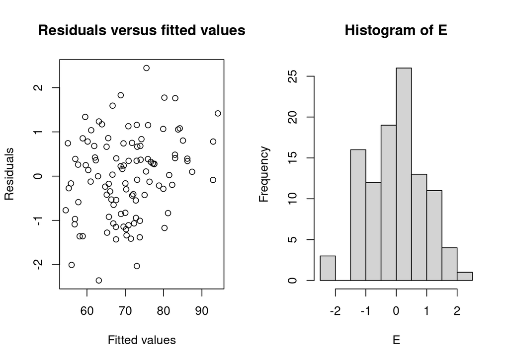

```r
model_as1=model_as.a
E <- resid(model_as1, type = "normalized")
Fit <- fitted(model_as1)
op <- par(mfrow = c(1, 2))
plot(x = Fit, y = E,
     xlab = "Fitted values", ylab = "Residuals",
     main = "Residuals versus fitted values")
hist(E, nclass = 15)
```

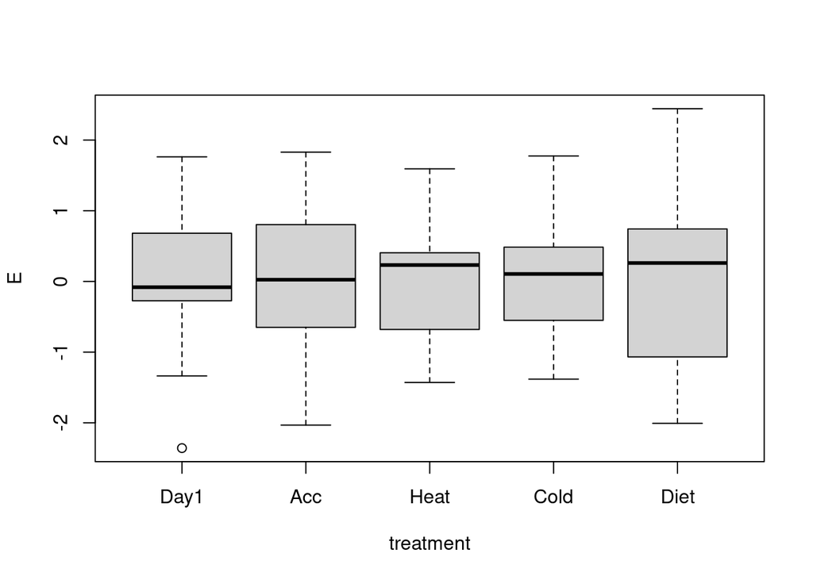

```r
par(op)
bp=boxplot(E ~ treatment,
           data = alph_div_tax_as)
```

```r
summary(model_as.a)
```

```
## Linear mixed-effects model fit by REML
##   Data: alph_div_tax_as
##       AIC      BIC    logLik
##   934.983 958.4295 -458.4915
##
## Random effects:
##  Formula: ~1 | cage
##         (Intercept)
## StdDev:     5.81433
##
##  Formula: ~1 | individual_id %in% cage
##         (Intercept) Residual
## StdDev:    8.422224 20.38083
##
## Correlation Structure: Continuous AR(1)
##  Formula: ~as.numeric(days) | cage/individual_id
##  Parameter estimate(s):
##       Phi
## 0.2000667
## Fixed effects:  diversity ~ treatment
##                  Value Std.Error DF   t-value p-value
## (Intercept)   64.02810  5.494296 79 11.653560  0.0000
## treatmentAcc  11.12264  6.306979 79  1.763545  0.0817
## treatmentHeat  9.90226  6.394579 79  1.548540  0.1255
## treatmentCold  9.86497  6.307017 79  1.564126  0.1218
## treatmentDiet -0.79601  6.225929 79 -0.127854  0.8986
##  Correlation:
##               (Intr) trtmnA trtmnH trtmnC
## treatmentAcc  -0.574
## treatmentHeat -0.567  0.493
## treatmentCold -0.574  0.500  0.493
## treatmentDiet -0.581  0.507  0.500  0.507
##
## Standardized Within-Group Residuals:
##         Min          Q1         Med          Q3         Max
## -2.35827091 -0.64938041  0.09777876  0.68155759  2.44381609
##
## Number of Observations: 105
## Number of Groups:
##                    cage individual_id %in% cage
##                       5                      22
```

```r
anova(model_as.a)
```

```
##             numDF denDF  F-value p-value
## (Intercept)     1    79 342.5953  <.0001
## treatment       4    79   1.7623  0.1448
```

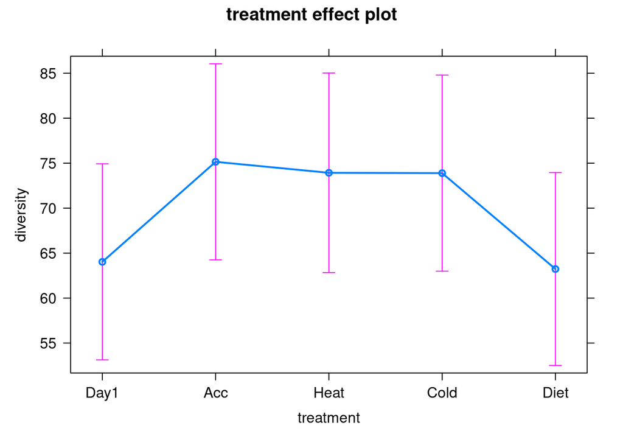

```r
plot(allEffects(model_as.a))
```

Pairwise comparison of treatments to assess where the significant effects are

```r
summary(glht(model_as.a, linfct = mcp(treatment=contr),
                   test = adjusted("holm")))
```

```
##
##   Simultaneous Tests for General Linear Hypotheses
##
## Multiple Comparisons of Means: User-defined Contrasts
##
##
## Fit: lme.formula(fixed = diversity ~ treatment, data = alph_div_tax_as,
##     random = ~1 | cage/individual_id, correlation = corCAR1(form = ~as.numeric(days)))
##
## Linear Hypotheses:
##                 Estimate Std. Error z value Pr(>|z|)
## Day1-Acc == 0  -11.12264    6.30698  -1.764    0.248
## Acc-Heat == 0    1.22038    6.39240   0.191    0.999
## Heat-Cold == 0   0.03729    6.39240   0.006    1.000
## Cold-Diet == 0  10.66098    6.22593   1.712    0.272
## (Adjusted p values reported -- single-step method)
```

```r
#plot_model(model_as1, type='Day1d', terms = c('treatment'))
```

################Start if the Crocidura taxonomic linear models########################

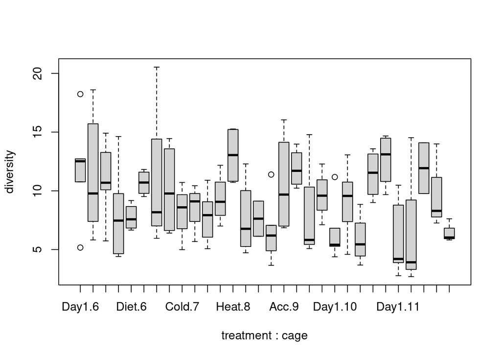

```r
boxplot(diversity~treatment*cage,data = alph_div_tax_cr)
```

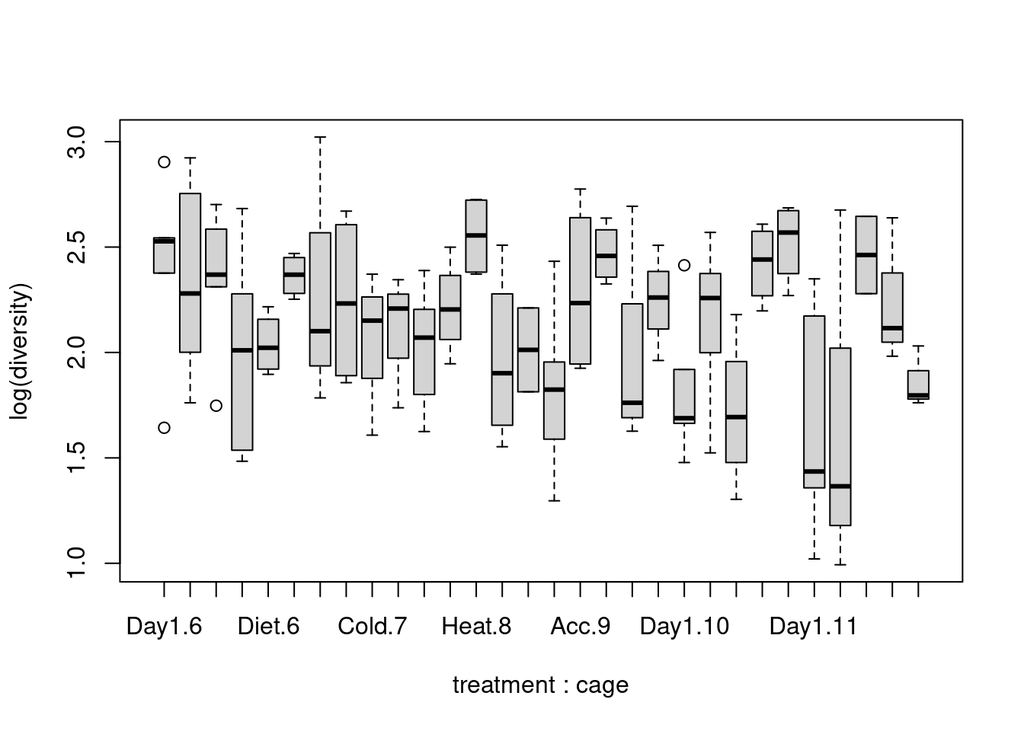

```r
boxplot(log(diversity)~treatment*cage,data = alph_div_tax_cr)
```

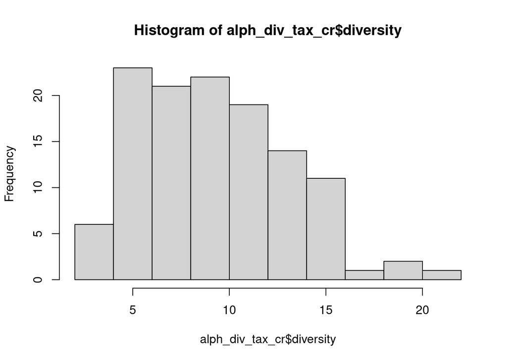

```r
hist(alph_div_tax_cr$diversity)
```

```r
#model_cr.a <- lme(diversity~treatment,
                  #random = ~1|cage/individual_id,
                  #correlation = corCAR1(form = ~ as.numeric(days)),
                  #data=alph_div_tax_cr)
model_cr.b <- lme(diversity~treatment,
                  random = ~1|cage,
                  data=alph_div_tax_cr)
model_cr.c <- lme(diversity~treatment,
                  random = ~1|individual_id,
                  correlation = corCAR1(form = ~ as.numeric(days)),
                  data=alph_div_tax_cr)
model_cr.e <- lm(diversity~treatment,
                  data=alph_div_tax_cr)

#AIC(model_cr.a) #657.3954
AIC(model_cr.b) #654.6046
```

```
## [1] 654.6036
```

```r
AIC(model_cr.c) #655.3954
```

```
## [1] 656.4563
```

```r
#AIC(model_cr.d) #NA
AIC(model_cr.e) #658.816
```

```
## [1] 658.8157
```

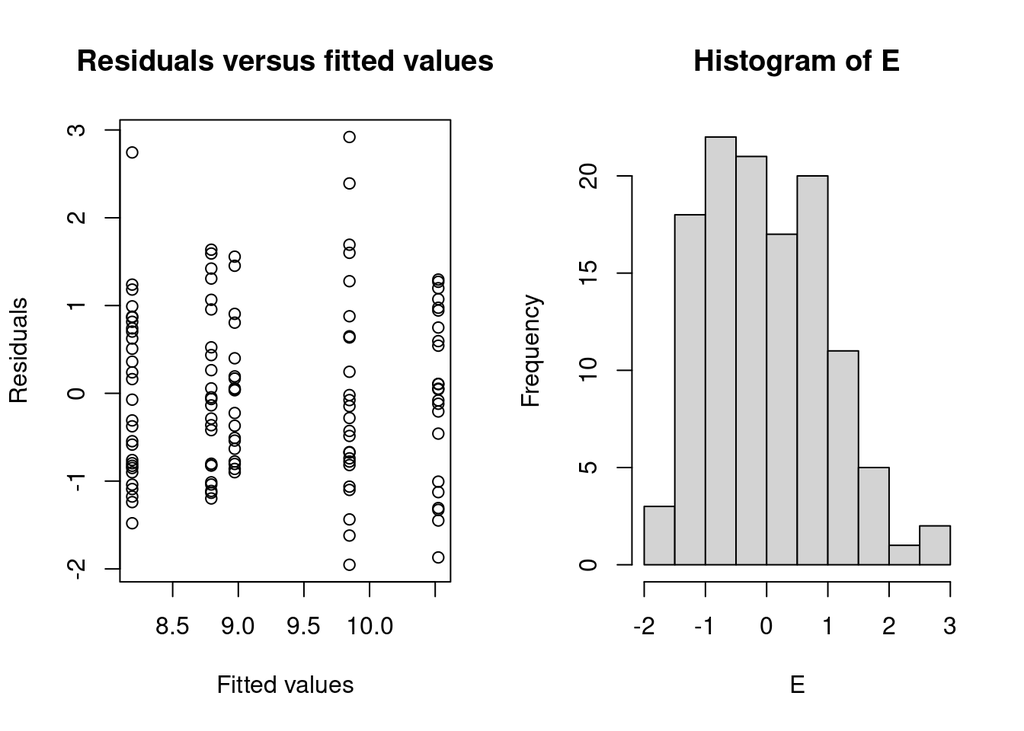

```r
model_cr1=model_cr.b
E <- resid(model_cr1, type = "normalized")
Fit <- fitted(model_cr1)
op <- par(mfrow = c(1, 2))
plot(x = Fit, y = E,
     xlab = "Fitted values", ylab = "Residuals",
     main = "Residuals versus fitted values")
hist(E, nclass = 15)
```

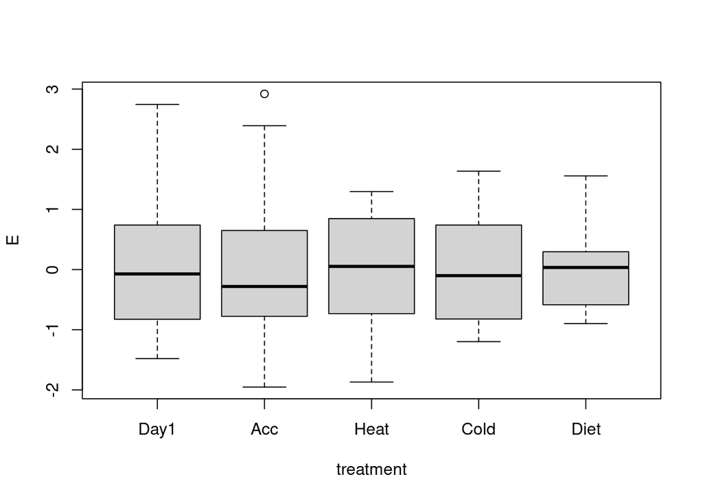

```r
par(op)
bp=boxplot(E ~ treatment,
           data = alph_div_tax_cr)
```

```r
anova(model_cr1)
```

```
##             numDF denDF  F-value p-value
## (Intercept)     1   110 762.8574  <.0001
## treatment       4   110   1.5882  0.1825
```

Pairwise comparison of treatments

```r
summary(glht(model_cr1, linfct = mcp(treatment=contr_cr),
                   test = adjusted("holm")))
```

```
##
##   Simultaneous Tests for General Linear Hypotheses
##
## Multiple Comparisons of Means: User-defined Contrasts
##
##
## Fit: lme.formula(fixed = diversity ~ treatment, data = alph_div_tax_cr,
##     random = ~1 | cage)
##
## Linear Hypotheses:
##                Estimate Std. Error z value Pr(>|z|)
## Day1-Acc == 0   -1.6551     0.9988  -1.657    0.302
## Acc-Heat == 0   -0.6770     1.0574  -0.640    0.924
## Heat-Cold == 0   1.7296     1.0679   1.620    0.322
## Cold-Diet == 0  -0.1784     1.1239  -0.159    1.000
## (Adjusted p values reported -- single-step method)
```

################Start of functional alpha diversity Apodemus#################

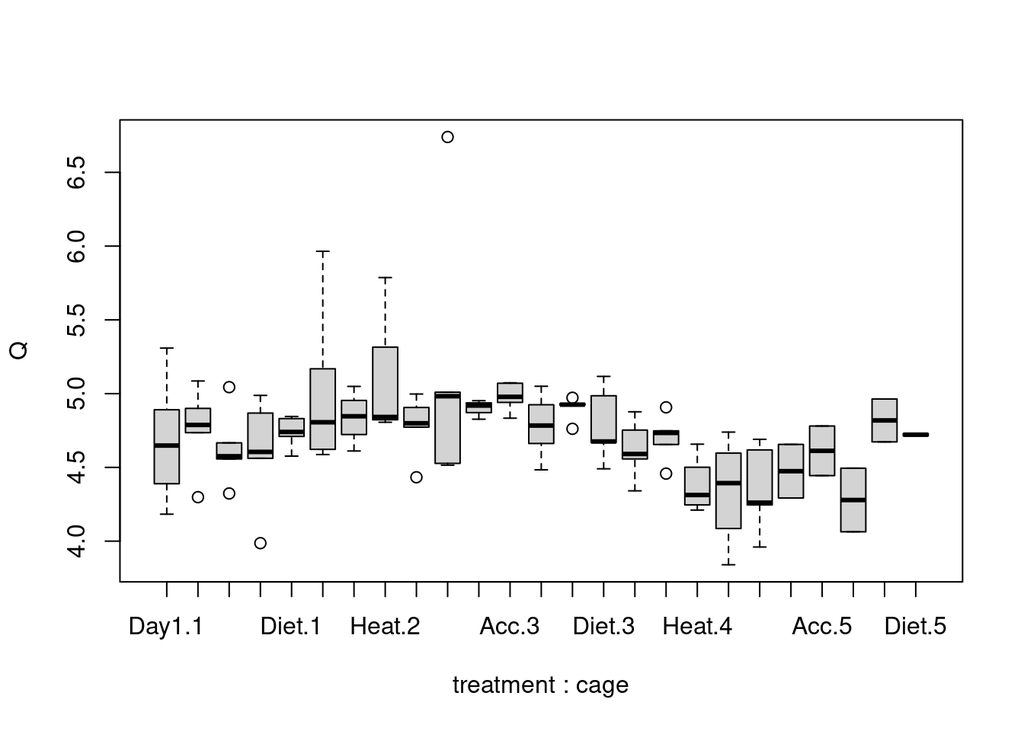

```r
boxplot(Q~treatment*cage,data = alph_div_fd_as)
```

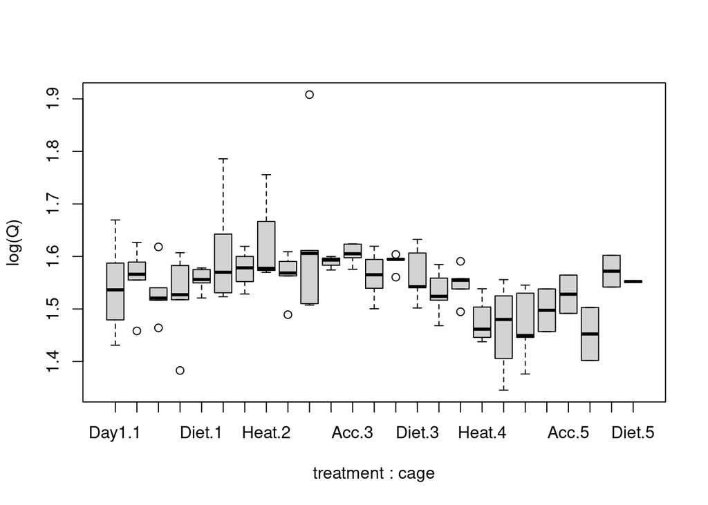

```r
boxplot(log(Q)~treatment*cage,data = alph_div_fd_as)
```

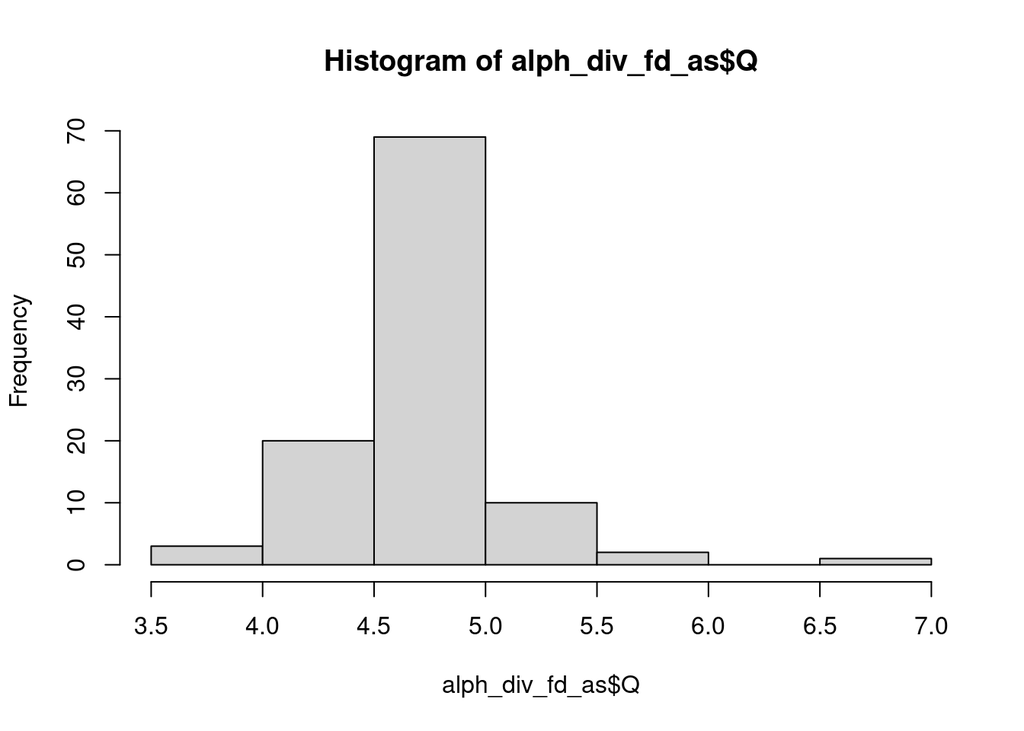

```r
hist(alph_div_fd_as$Q)
```

```r
model_as.a_fd <- lme(Q~treatment,
                  random = ~1|cage/individual_id,
                  correlation = corCAR1(form = ~ as.numeric(days)),
                  data=alph_div_fd_as)
model_as.b_fd <- lme(Q~treatment,
                  random = ~1|individual_id,
                  correlation = corCAR1(form = ~ as.numeric(days)),
                  data=alph_div_fd_as)
model_as.c_fd <- lme(Q~treatment,
                  random = ~1|cage,
                  data=alph_div_fd_as)
model_as.d_fd <- lme(Q~treatment,
                  random = ~1|cage/individual_id,
                  data=alph_div_fd_as)
model_as.e_fd <- lm(Q~treatment,
                  data=alph_div_fd_as)
AIC(model_as.a_fd) #292.0188
```

```
## [1] 99.89254
```

```r
AIC(model_as.b_fd) #290.6965
```

```
## [1] 102.1735
```

```r
AIC(model_as.c_fd) #292.2867
```

```
## [1] 103.5273
```

```r
AIC(model_as.d_fd) #292.3475
```

```
## [1] 98.50968
```

```r
AIC(model_as.e_fd) #286.632
```

```
## [1] 101.7711
```

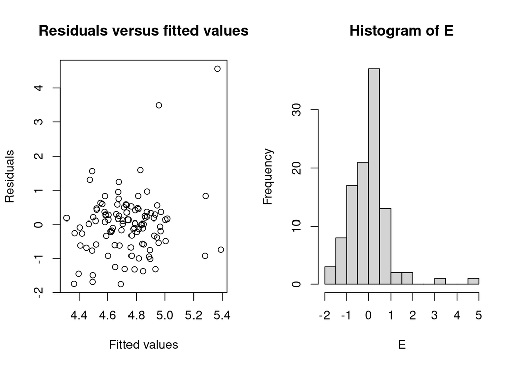

```r
model_as1_fd=model_as.a_fd
E <- resid(model_as1_fd, type = "normalized")
Fit <- fitted(model_as.a_fd)
op <- par(mfrow = c(1, 2))
plot(x = Fit, y = E,
     xlab = "Fitted values", ylab = "Residuals",
     main = "Residuals versus fitted values")
hist(E, nclass = 15)
```

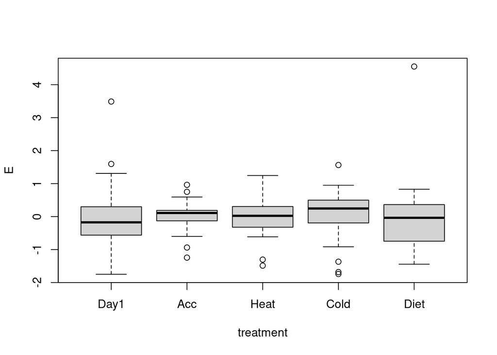

```r
par(op)
bp=boxplot(E ~ treatment,
           data = alph_div_fd_as)
```

We observe no significant difference in the effect of treatment on functional alpha diversity

```r
anova(model_as1_fd)
```

```
##             numDF denDF   F-value p-value
## (Intercept)     1    79 2395.8134  <.0001
## treatment       4    79    1.0515  0.3862
```

This is useless - ignore it for now but just wanted to sanity check

```r
summary(glht(model_as1_fd, linfct = mcp(treatment=contr),
                   test = adjusted("holm")))
```

```
##
##   Simultaneous Tests for General Linear Hypotheses
##
## Multiple Comparisons of Means: User-defined Contrasts
##
##
## Fit: lme.formula(fixed = Q ~ treatment, data = alph_div_fd_as, random = ~1 |
##     cage/individual_id, correlation = corCAR1(form = ~as.numeric(days)))
##
## Linear Hypotheses:
##                 Estimate Std. Error z value Pr(>|z|)
## Day1-Acc == 0  -0.047278   0.084617  -0.559    0.954
## Acc-Heat == 0   0.154437   0.092162   1.676    0.296
## Heat-Cold == 0  0.004129   0.093202   0.044    1.000
## Cold-Diet == 0 -0.087036   0.089655  -0.971    0.756
## (Adjusted p values reported -- single-step method)
```

####################Start of the Crocidura functional alpha diversity

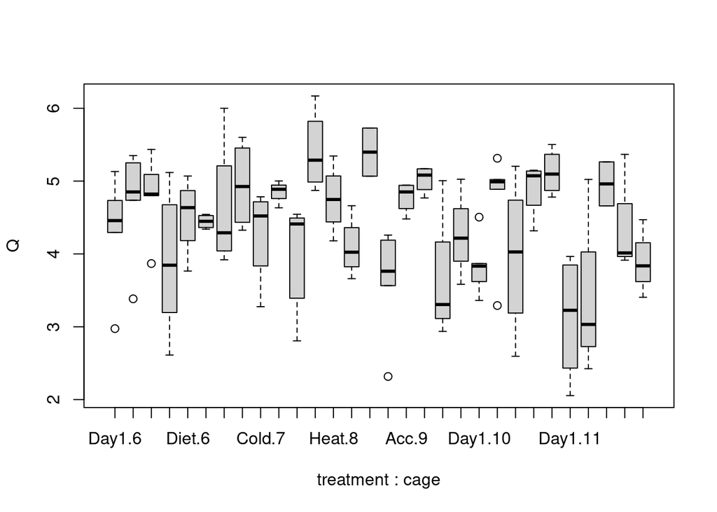

```r
boxplot(Q~treatment*cage,data = alph_div_fd_cr)
```

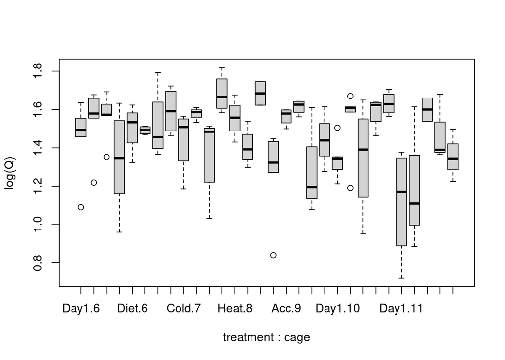

```r
boxplot(log(Q)~treatment*cage,data = alph_div_fd_cr)
```

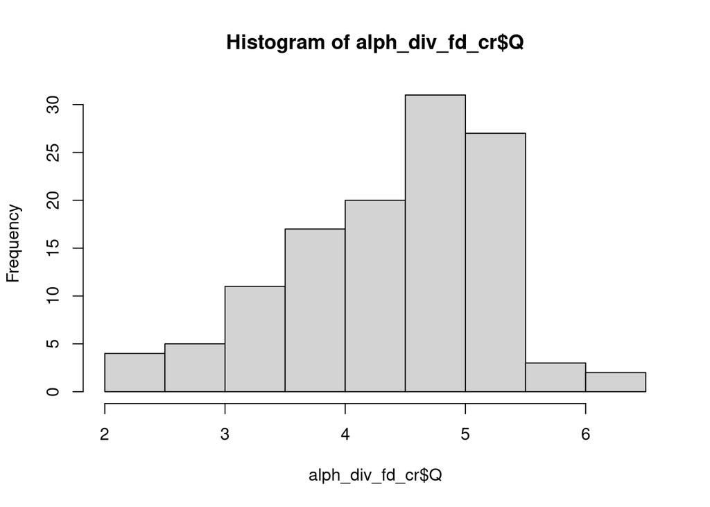

```r
hist(alph_div_fd_cr$Q)
```

```r
model_cr.a_fd <- lme(Q~treatment,
                  random = ~1|cage/individual_id,
                  correlation = corCAR1(form = ~ as.numeric(days)),
                  data=alph_div_fd_cr)
model_cr.b_fd <- lme(Q~treatment,
                  random = ~1|individual_id,
                  correlation = corCAR1(form = ~ as.numeric(days)),
                  data=alph_div_fd_cr)
model_cr.c_fd <- lme(Q~treatment,
                  random = ~1|cage,
                  data=alph_div_fd_cr)
model_cr.d_fd <- lme(Q~treatment,
                  random = ~1|individual_id,
                  data=alph_div_fd_cr)
model_cr.e_fd <- lm(Q~treatment,
                  data=alph_div_fd_cr)


AIC(model_cr.a_fd) #377.5765
```

```
## [1] 296.1236
```

```r
AIC(model_cr.b_fd) #376.0824
```

```
## [1] 295.0993
```

```r
AIC(model_cr.c_fd) #379.5765
```

```
## [1] 292.7458
```

```r
AIC(model_cr.d_fd) #374.0913
```

```
## [1] 293.5985
```

```r
AIC(model_cr.e_fd) #370.5743
```

```
## [1] 283.5407
```

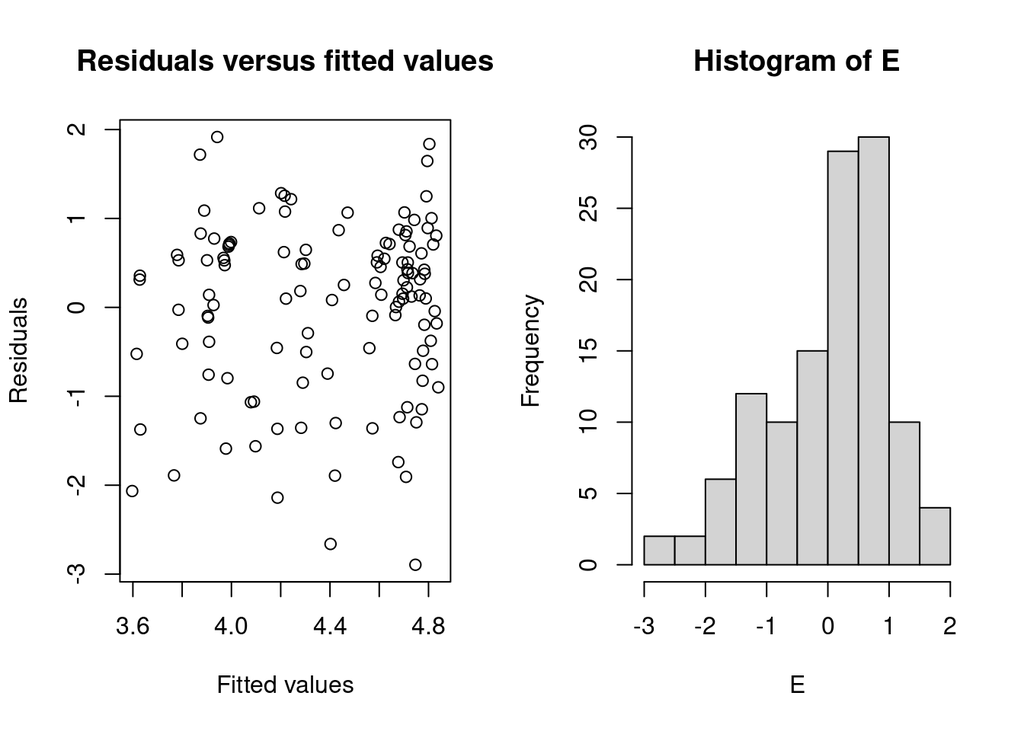

```r
model_cr1_fd=model_cr.a_fd
E <- resid(model_cr1_fd, type = "normalized")
Fit <- fitted(model_cr1_fd)
op <- par(mfrow = c(1, 2))
plot(x = Fit, y = E,
     xlab = "Fitted values", ylab = "Residuals",
     main = "Residuals versus fitted values")
hist(E, nclass = 15)
```

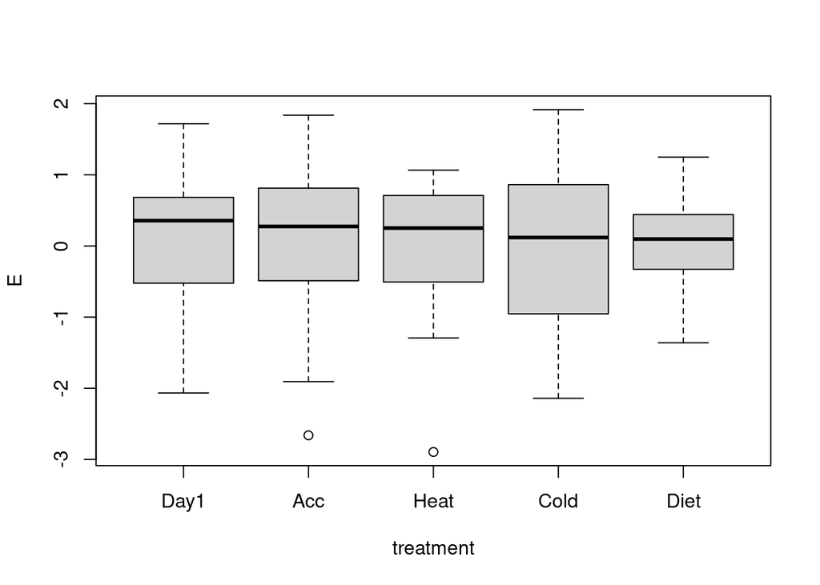

```r
par(op)
bp=boxplot(E ~ treatment,
           data = alph_div_tax_cr)
```

We have a highly significant effect of treatment on functional alpha diversity

```r
anova(model_cr1_fd)
```

```
##             numDF denDF   F-value p-value
## (Intercept)     1    87 1746.2174  <.0001
## treatment       4    87    7.1243   1e-04
```

```r
summary(glht(model_cr1_fd, linfct = mcp(treatment=contr_cr),
                   test = adjusted("holm")))
```

```
##
##   Simultaneous Tests for General Linear Hypotheses
##
## Multiple Comparisons of Means: User-defined Contrasts
##
##
## Fit: lme.formula(fixed = Q ~ treatment, data = alph_div_fd_cr, random = ~1 |
##     cage/individual_id, correlation = corCAR1(form = ~as.numeric(days)))
##
## Linear Hypotheses:
##                Estimate Std. Error z value Pr(>|z|)
## Day1-Acc == 0  -0.80500    0.19058  -4.224   <0.001 ***
## Acc-Heat == 0  -0.03635    0.21175  -0.172   0.9994
## Heat-Cold == 0  0.52930    0.21523   2.459   0.0509 .
## Cold-Diet == 0 -0.48094    0.22559  -2.132   0.1149
## ---
## Signif. codes:  0 '***' 0.001 '**' 0.01 '*' 0.05 '.' 0.1 ' ' 1
## (Adjusted p values reported -- single-step method)
```

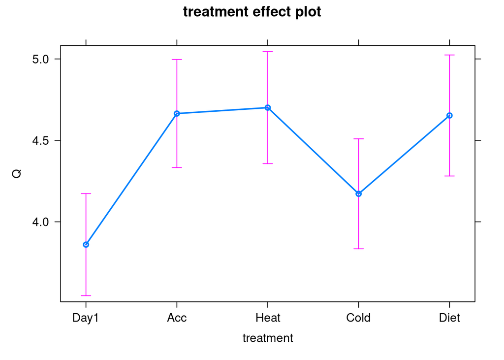

```r
plot(allEffects(model_cr1_fd))
```

########Phylogenetic linear models

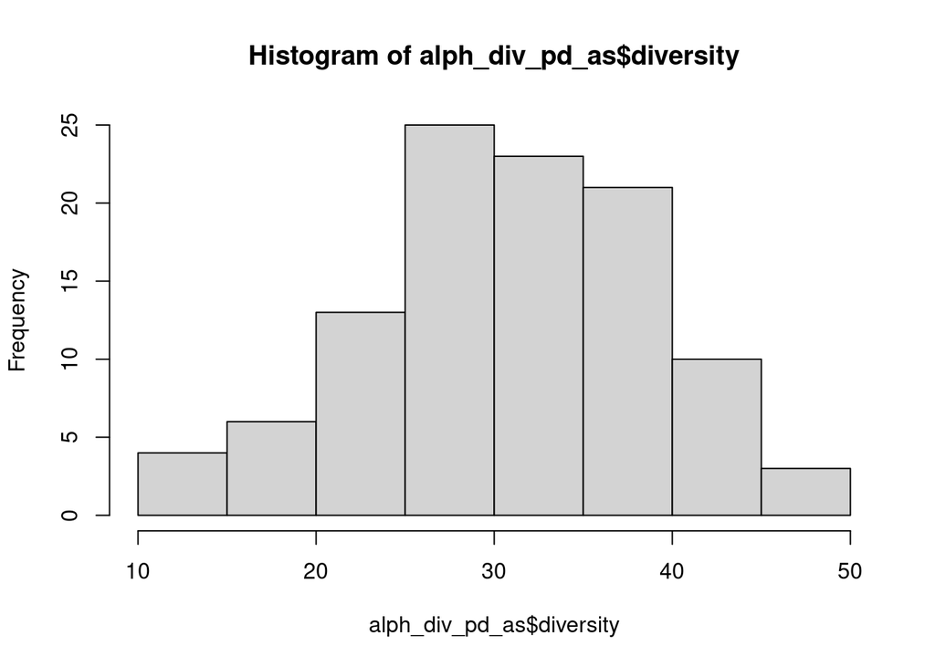

```r
hist(alph_div_pd_as$diversity)
```

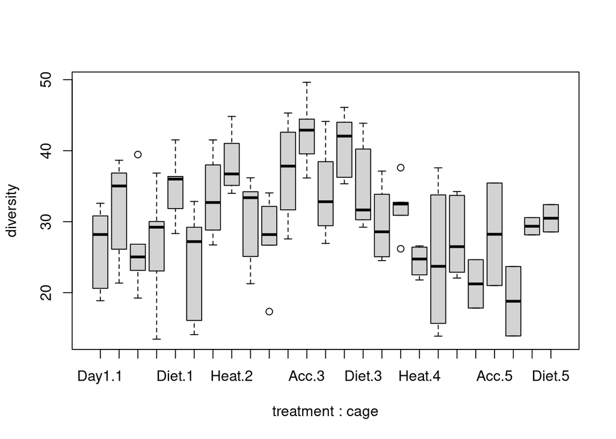

```r
boxplot(diversity~treatment*cage,data = alph_div_pd_as)
```

Assessment of log transformation it looks tighter, however the non-transformed data still looks ok to me so i will continue with this

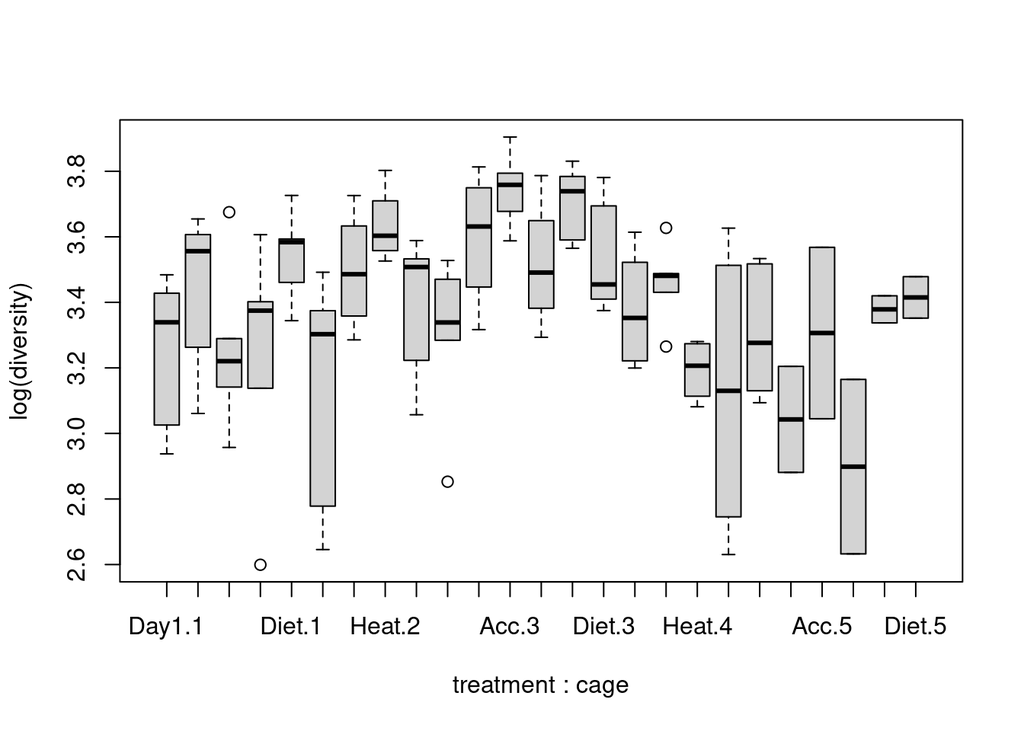

```r
boxplot(log(diversity)~treatment*cage,data = alph_div_pd_as)
```

Create the models for comparison - including the random effects results in the lowest AIC

```r
###Try to include the other factors
model_as.a.pd <- lme(diversity~treatment,
                  random = ~1|cage/individual_id,
                  correlation = corCAR1(form = ~ as.numeric(days)),
                  data=alph_div_pd_as)
model_as.b.pd  <- lme(diversity~treatment,
                  random = ~1|individual_id,
                  data=alph_div_pd_as)
model_as.c.pd  <- lme(diversity~treatment,
                  random = ~1|individual_id,
                  correlation = corCAR1(form = ~ as.numeric(days)),
                  data=alph_div_pd_as)
model_as.d.pd  <- lme(diversity~treatment,
                  random = ~1|cage,
                  data=alph_div_pd_as)
model_as.e.pd  <- lm(diversity~treatment,
                  data=alph_div_pd_as)

anova(model_as.a.pd,model_as.b.pd,model_as.c.pd,model_as.e.pd)
```

```
##               Model df      AIC      BIC    logLik   Test   L.Ratio p-value
## model_as.a.pd     1  9 707.3642 730.8108 -344.6821
## model_as.b.pd     2  7 712.2172 730.4534 -349.1086 1 vs 2  8.852929  0.0120
## model_as.c.pd     3  8 714.2171 735.0584 -349.1085 2 vs 3  0.000091  0.9924
## model_as.e.pd     4  6 724.2139 739.8449 -356.1069 3 vs 4 13.996777  0.0009
```